# 시계열분석 기말과제

2015122030 Hyojeong Yang

2019-06-18

## Time series analysis final assignment problem 6.

```r
library(forecast)

#load & check data
erate <- read.table("economic_rate.csv", header=F)
head(erate)
```

```
##     V1
## 1 56.6
## 2 56.6
## 3 57.8
## 4 59.1
## 5 60.0
## 6 59.8
```

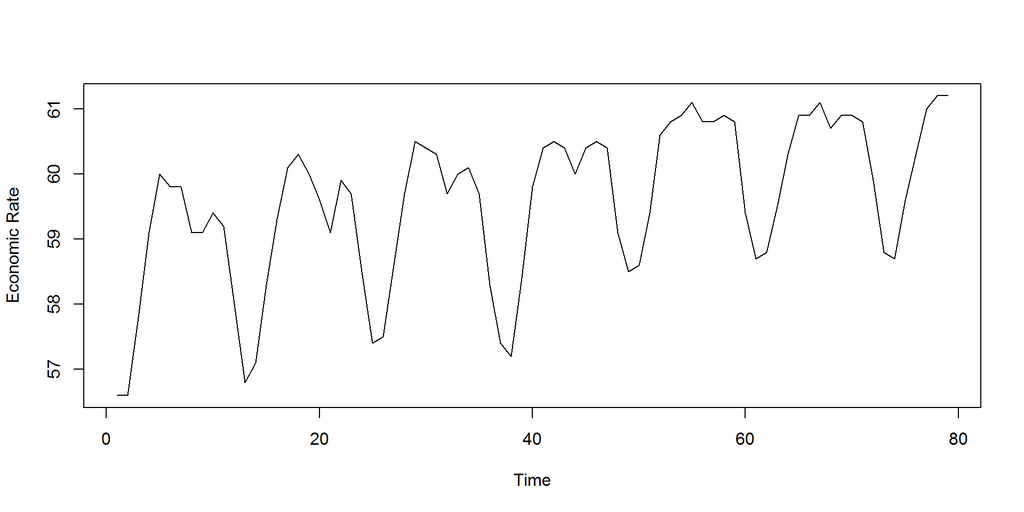

```r
#make data as time series
erate.ts <- ts(erate)

#make time series plot
plot.ts(erate.ts, xlab="Time", ylab="Economic Rate")
```

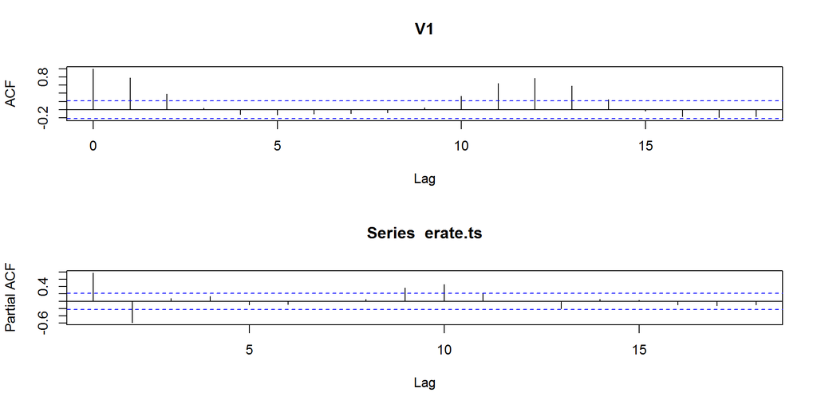

```r
#check ACF and PACF
par(mfrow=c(2,1))
acf(erate.ts)
pacf(erate.ts)
```

```r
#check if difference is needed
ndiffs(erate.ts)
```

```
## [1] 1
```

시도표 분석 결과 12시차 단위로 약간의 증가 추세와 계절 성분이 있는 것으로 보인다.  
ACF, PACF에서는 계절 성분을 확인할 수 있었다.  
ndiffs 테스트 결과 차분의 필요성이 있는 것이 확인되었으므로, 계절 차분을 수행하는 것이 바람직하다.

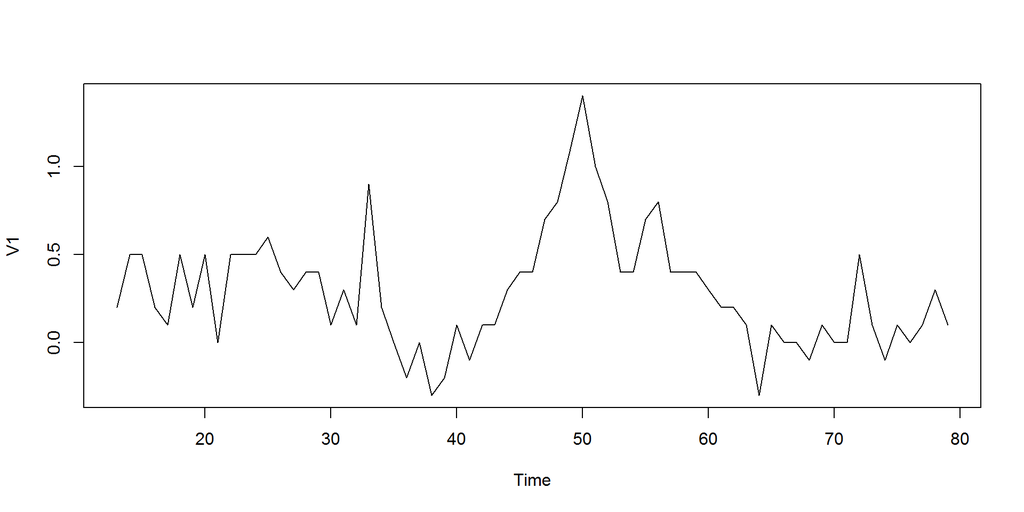

```r
#difference
diff_erate <- diff(erate.ts, lag=12)
plot.ts(diff_erate)
```

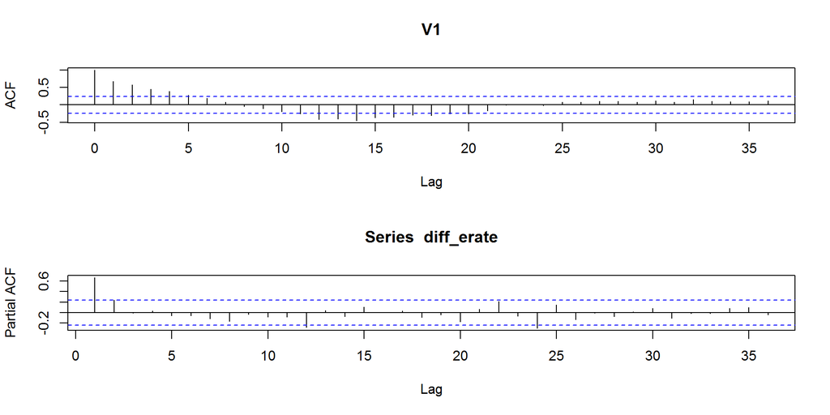

```r
#ACF, PACF
par(mfrow=c(2,1))
acf(diff_erate, lag = 36)
pacf(diff_erate, lag = 36)
```

계절차분 후 계절성분이 제거된 것을 확인할 수 있다.  
ACF와 PACF를 볼 때 비계절 모형은 AR(1), 계절 모형은 MA(1) 모형으로 추정된다.

```r
#find best ARIMA model
auto.arima(erate.ts) #일반 차분으로 충분
```

```
## Series: erate.ts
## ARIMA(2,1,1)
##
## Coefficients:
##          ar1      ar2      ma1
##       1.3373  -0.7468  -0.8953
## s.e.  0.0766   0.0765   0.0446
##
## sigma^2 estimated as 0.2242:  log likelihood=-51.97
## AIC=111.95   AICc=112.49   BIC=121.37
```

```r
auto.arima(diff_erate) #계절차분 후: 차분 필요 없음
```

```
## Series: diff_erate
## ARIMA(2,0,0) with non-zero mean
##
## Coefficients:
##          ar1     ar2    mean
##       0.5079  0.2289  0.2830
## s.e.  0.1186  0.1187  0.1046
##
## sigma^2 estimated as 0.05892:  log likelihood=0.99
## AIC=6.02   AICc=6.67   BIC=14.84
```

auto.arima는 ARIMA를 추천했기 때문에 추천받은 ARIMA 모형과 추정한 SARIMA 모형을 비교해보기로 한다.

```r
#compare two models
arima_erate <- arima(erate.ts, c(2, 1, 1)) #계절차분 X
sarima_erate <- arima(erate.ts, c(2, 0, 0), seasonal = list(order = c(0, 1, 1), period = 12)) #계절차분

arima_erate; sarima_erate
```

```
##
## Call:
## arima(x = erate.ts, order = c(2, 1, 1))
##
## Coefficients:
##          ar1      ar2      ma1
##       1.3373  -0.7468  -0.8953
## s.e.  0.0766   0.0765   0.0446
##
## sigma^2 estimated as 0.2155:  log likelihood = -51.97,  aic = 111.95
```

```
##
## Call:
## arima(x = erate.ts, order = c(2, 0, 0), seasonal = list(order = c(0, 1, 1),
##     period = 12))
##
## Coefficients:
##         ar1     ar2     sma1
##       0.647  0.2735  -0.3844
## s.e.  0.123  0.1190   0.1435
##
## sigma^2 estimated as 0.05232:  log likelihood = 2.14,  aic = 3.72
```

ARIMA 모형보다 SARIMA 모형의 AIC가 훨씬 작으므로 SARIMA(2,0,0)(0,1,1)[12] 모형을 사용하기로 한다.

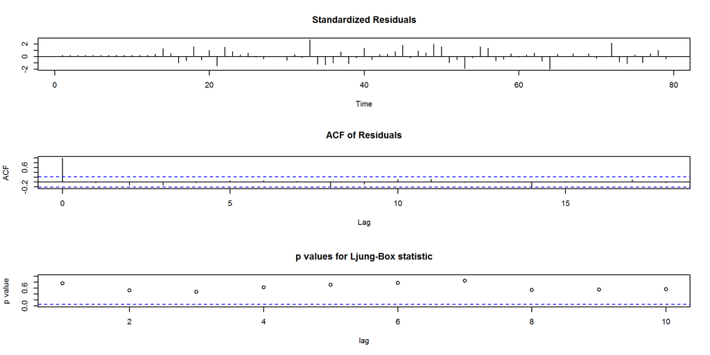

```r
#test residual
tsdiag(sarima_erate)
```

잔차검정 결과 모형에서 아무런 문제도 발견되지 않으므로 (정상성, 독립성, 등분산성 만족) 이 모형을 사용해 값을 예측하기로 한다.

```r
#predict 12 data ahead
pred_erate <- forecast(sarima_erate, h = 12)
pred_erate
```

```
##    Point Forecast    Lo 80    Hi 80    Lo 95    Hi 95
## 80       60.83902 60.54589 61.13216 60.39072 61.28733
## 81       60.97594 60.62679 61.32508 60.44197 61.50991
## 82       61.01555 60.61174 61.41936 60.39797 61.63312
## 83       60.88909 60.44569 61.33249 60.21096 61.56721
## 84       59.79853 59.32222 60.27484 59.07007 60.52699
## 85       58.83386 58.33054 59.33718 58.06409 59.60362
## 86       58.79058 58.26457 59.31659 57.98612 59.59505
## 87       59.63998 59.09478 60.18517 58.80617 60.47378
## 88       60.43311 59.87155 60.99466 59.57428 61.29193
## 89       61.05422 60.47864 61.62980 60.17395 61.93449
## 90       61.18098 60.59333 61.76862 60.28225 62.07971
## 91       61.23236 60.63428 61.83043 60.31768 62.14704
```

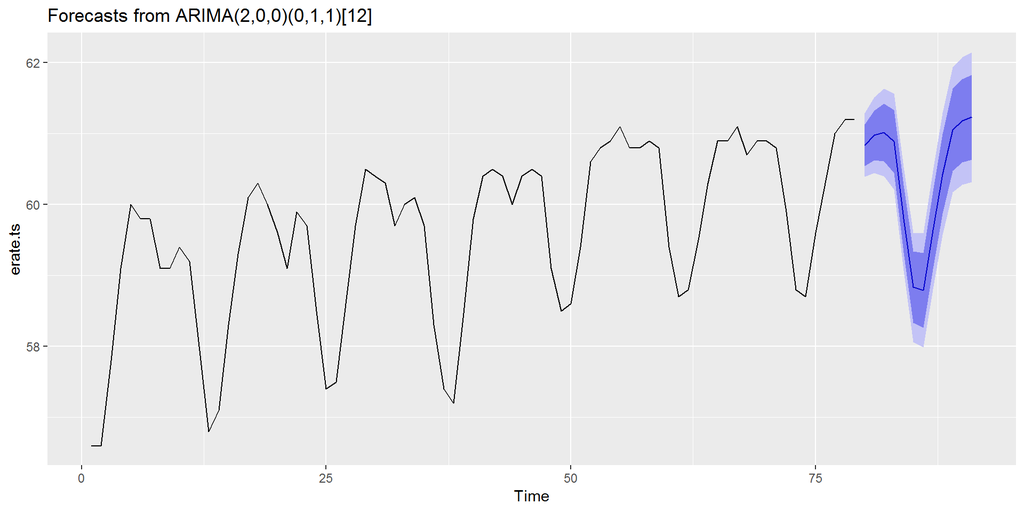

```r
#new time series plot with predicted & fitted data
autoplot(pred_erate)
```

예측값을 생성했고, 예측값이 포함된 새 시도표를 생성했다.